# Allocation of a swarm of machine agents in a grid

Jordi Rof

2022-12-14

# 1 Assignment description

Propose a scheme of coordination optimally allocating a distributed swarm of heterogeneous machine agents in the provision of real-time ancillary/balancing<sup>1</sup> services market.

Provide a definition of a machine’s<sup>2</sup> capability. Provide a definition of ancillary/balancing markets.

1. Balancing agents provide a balance between supply and demand to ensure the security and quality of electricity supply. Ancillary services are the functions which TSOs contract, so they guarantee that system security.
2. A machine here means any electrical machine, contributing to balancing and that deploys a control strategy enabling the clean and stable electricity output.

# 2 Allocation exercise

The objective of this exercise is to describe and solve a scheme of coordination optimally allocating a swarm of machine agents. Allocation in this exercise primarily implies deciding the number of machine agents deployed to the grid. The decision is taken with the intention of maximizing profits.

The machine agents in this exercise are relatively simple. They consists of machines with the ability of deciding at which price to store energy and at which price to release it to the grid. The decision is made following simple price-based rules, therefore the machines do not consider the timing in their decision making. These machines are bounded by energy storage capacity. Importantly, the intervention of the machine agents has an impact on which power plants are operational in each discrete point in time.

The key parameters of the exercise are listed below:

## 2.1 The grid system

The system in which the machine agents operate is a standard electricity grid. The grid consists of generation, transmission and distribution. Electricity is generated in power plants, transmitted via high tension lines and distributed at low voltages. It is important to bear in mind that the machine agents operate in the day-ahead energy market and energy demand is exogenous.

## 2.2 Energy supply

Energy is generated in power plants that provide constant energy supply (in the simulation each power plant provides 70 MW, so they could be considered very small gas power plants). The assumption of constant supply is made for simplicity of the optimization / allocation problem. The minimum number of suppliers needed in order to achieve fluctuating prices is two (see wholesale energy price). In the calibration of this exercise there are the price at which power plants are willing to sell their energy are listed in the table below, in column ‘Cost (Euro/MWh)’.

| Capactity (MW) | Cost (Euro/MWh) |
| --- | --- |
| 70 | 40 |
| 70 | 60 |
| 70 | 80 |
| 70 | 100 |

## 2.3 Energy demand

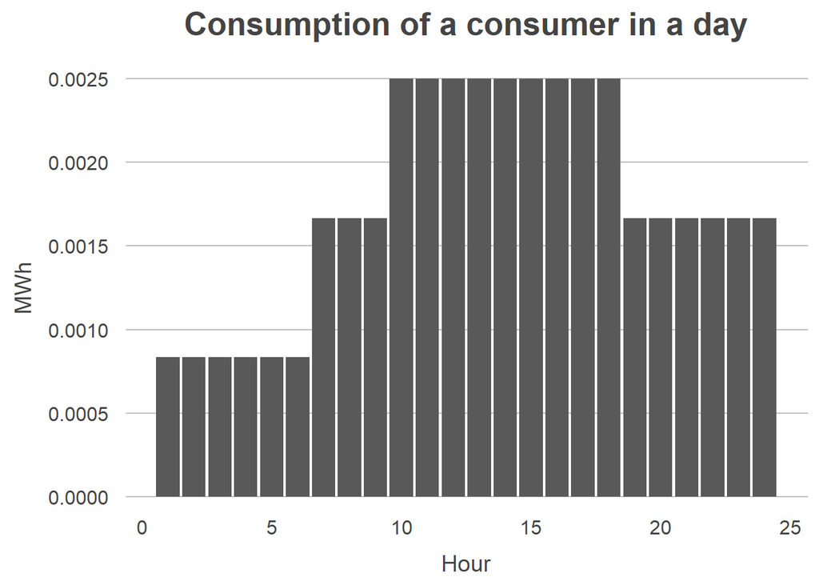

Figure 2.1: Energy consumption of a household over the day. In the simulation households are assumed to be identical.

## 2.4 Wholesale energy prices

Energy prices are assumed to be driven by supply (which is given but it can be turned on and off) and demand (which is variable, it changes every hour). The price system is inspired in the EU system in which energy is paid at the marginal cost of production (the cost of adding the next watt). The energy suppliers are ranked by cost of the KW/h in the day-ahead market. For simplicity, an intra-day market is not considered in the exercise. The suppliers are selected until the demand is covered, and all the suppliers are paid at the cut-off cost (the cost of the latest and most expensive producer). The prices and capacity are negotiated hour by hour in this example.

## 2.5 Functionality of the machine agents

The machine agents have the objective of maximizing profits by storing electricity when energy is negotiated at low prices (moments of low demand) and selling it in moments of high prices (high demand). For simplicity, there are no losses when energy is stored and released (efficiency is assumed to be 100%). Importantly, the storage capacity of the machine agents is limited, and the machines operate with simple price-based rules. For instance, store energy when it can be purchased under a threshold price, and release energy when it can be sold over a different threshold price.

## 2.6 Objective function of the “machine administrator” TSO

The agent allocating the machine agents is driven by profits. Income is generated by the activity of the machines. Each machine is assumed to have a fixed cost, and no operating cost. The problem of the “machine administrator” is thus an optimization problem.

The allocation of the machines is solved numerically, not analytically. Several simulations where the machines apply different buying and selling strategies (buying and selling at different prices) throughout the duration of the exercise are run. The machine administrator will chose the combination of strategy and number of machines that maximizes the profit.

## 2.7 Optimal allocation

The optimal allocation leads to 88 thousand euro of profits, 179.6 thousand euro of revenue, and it is described by the values of the key variables below:

- Selling price: 80
- Buying price: 40
- Number of machines: 5

Figure 2.2 visualizes the optimal decision and the performance of the three feasible strategies (selling price higher than purchasing price) that exist given the calibration chosen in the exercise.

Figures 2.3, 2.4 and 2.5 visualize how the optimal allocation (optimal strategy and number of machines) functions. Figure 2.3 shows how demand is met (storage vs. Generation) and when energy is stored. Figure 2.4 shows the evolution fo the charge through the periods of the simulation. Figure 2.5 shows the evolution of the cash flow.

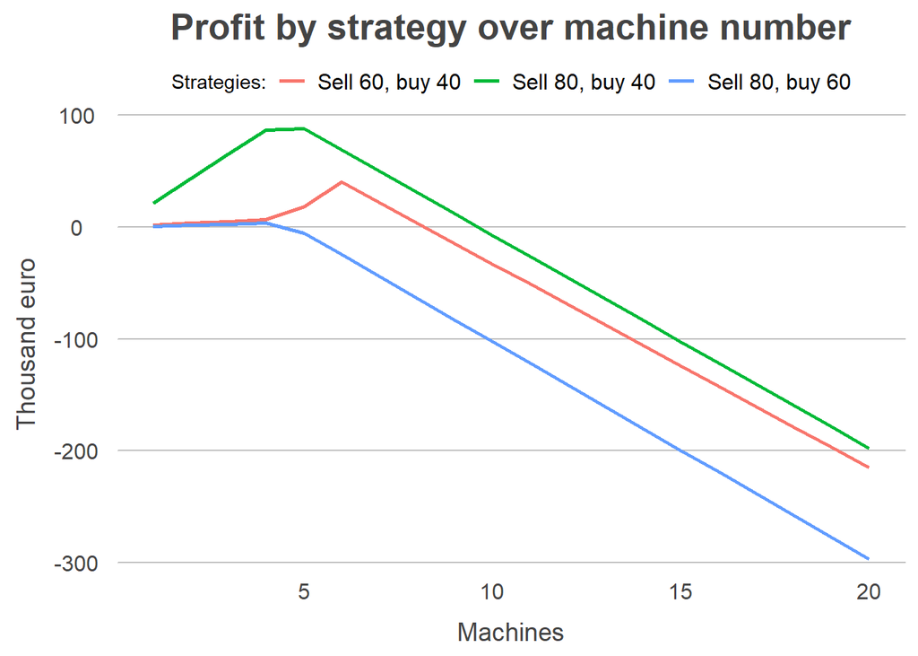

Figure 2.2: Profit produced by each purchasing/selling strategy as the number of machines increases. The optimal allocation is defined by the strategy and number of machines that maximizes profits.

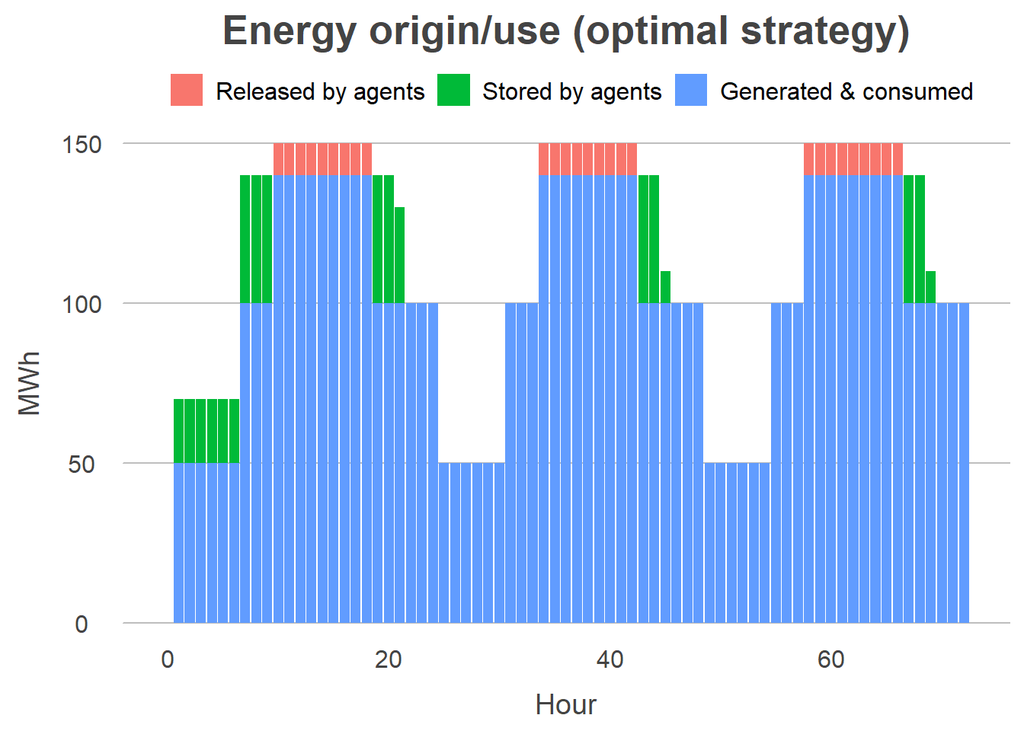

Figure 2.3: Use and origin of energy in the first three days of the optimal allocation.

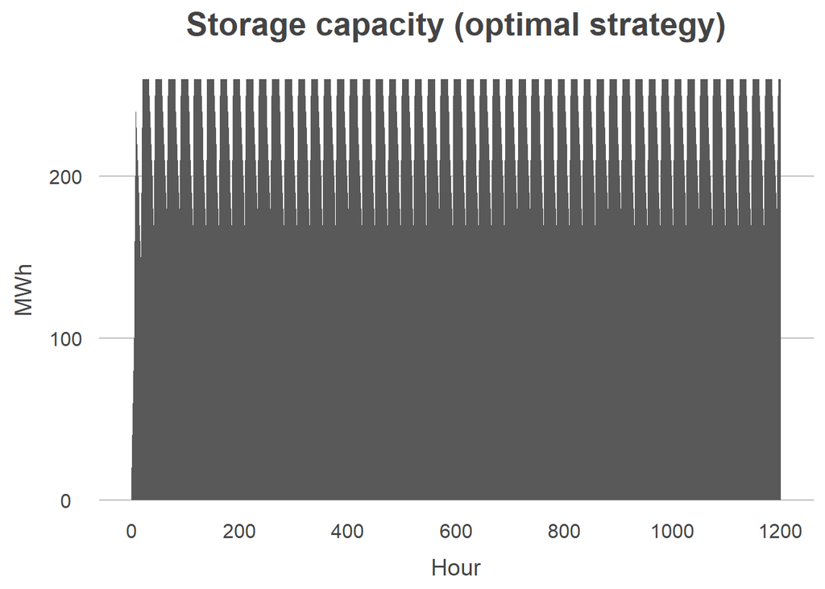

Figure 2.4: Evolution of energy storage storage over the whole period considered in the simulation for the optimal allocation.

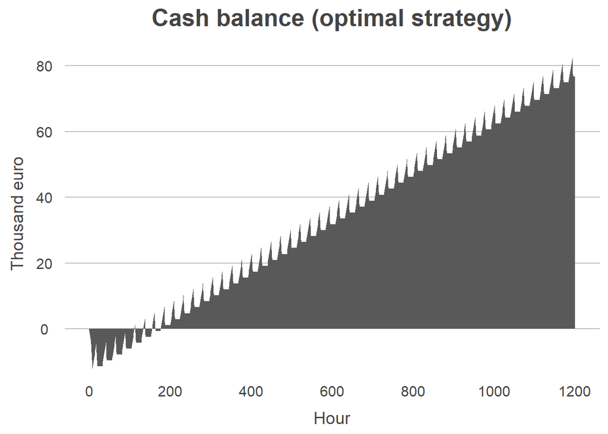

Figure 2.5: Evolution of cash balance over the whole period considered in the simulation for the optimal allocation.

# 3 Conclusion

The setup of the exercise and the setup allows to find an optimal allocation among the available options to the machine. The solution respects the physical boundaries (storage capacity) as well as the rules that govern the machines. The strategy produces profits when considering operating expenses, operating costs and variable costs (cost fo the machines). However, the limitations of the simple price setting rules are evident in charts 2.3 and 2.4. The simplistic rule leads to purchases of energy that could be lower, when demand is at 50 MWh. Also, the cycles of charge and discharge of the batteries do not make use of the battery’s full capacity, showing that the capacity allocation is not optimal either.

# 4 Critique and suggestions for improvement

The exercise described in this document is simplistic and has several obvious points for improvement. These are briefly discussed in the subsections below.

## 4.1 Grid system

The system described below ignores efficiency losses and voltage conversions. Another simplification assumption is that the machine agents operate at the transmission stage, without getting involved in the distribution phase. This obviously limits the potential of introducing more complex actors such as producer-consumers (prosumers).

## 4.2 Energy supply

The system could be more complex and realistic by 1) introducing additional producers with different cost structures, 2) by introducing seasonality and 3) introducing stochastic components in the power generation. For instance by assuming that other energy sources with this features enter the supply mix (e.g. wind or solar, they depend on factors that are not directly controlled/known by the grid operators).

## 4.3 Energy demand

The energy demand is deterministic and has a single profile that is mechanically repeated as the simulation evolves. It would be more realistic and interesting to consider a case with different seasonality types and a stochastic component.

## 4.4 Wholesale energy prices

While the price-setting mechanism is realistic (inspired in the EU model), it is limited by a reduced number of potential energy providers and also by its simplicity. The pricing environment would be richer by making the the supply side of the simulation more complex.

## 4.5 Functionality of the machine agents

The functionality of the machine agents is limited in at least two dimensions. First, machine agents can only store energy and release it. Their functionality could be enriched by assuming they can use the electricity produced at moments of low demand for a productive process that is not bounded by time restrictions (e.g. producing green hydrogen). Second, the machine agents do not have any forecasting ability whatsoever, they simply rely on energy price triggers to generate profits. Endowing the machines with forecasting abilities could lead to improvements in the result.

## 4.6 Objective function of the “machine administrator” TSO

The assumption is that the machine administrator is only driven by short-term profits. Temporal dynamics could be enriched by introducing long-term considerations, such as charging and discharging cycles affecting the expected lifespan of the machines. This would likely require the addition of a utility function with a discount factor. Other drivers of the utility could be added as well, such as the desire of stabilizing the grid.

## 4.7 Optimal allocation

The optimal allocation is only optimal conditional on the chosen set of rules that bound machine agents.

# 5 Sources

- Source code: https://github.com/Jordirof/machineAgents
- Energy demand patterns: https://www.eia.gov/todayinenergy/detail.php?id=42915
- Electricity average consumption: https://www.eia.gov/tools/faqs/faq.php?id=97&t=3#
- EU energy market design: https://eur-lex.europa.eu/legal-content/EN/ALL/?uri=CELEX:32009R0714
- EU grid price setting and related issues: https://www.reuters.com/world/europe/how-could-europe-cap-surging-energy-prices-2022-08-30/